# ISYE 6402 Homework 4

# Background

For this data analysis, you will again analyze the currency exchange data but to a greater extent and including two different currencies for comparison. File *DailyCurrencyData.csv* contains the *daily* exchange rate of USD/JPY and USD/CNY from January 2010 through December 31st 2021. File *MonthlyCurrencyData.csv* contains the *monthly* exchange rate of USD/JPY and USD/CNY for the same time period. Similarly to homework 2, we will aggregate the daily data into weekly data. We will compare our analysis using ARMA modeling on both weekly and monthly data for the two currencies.

```r
library(zoo)
library(lubridate)
library(mgcv)
```

# Instructions on reading the data

To read the data in `R`, save the file in your working directory (make sure you have changed the directory if different from the R working directory) and read the data using the `R` function `read.csv()`

```r
daily <- read.csv("DailyCurrencyData.csv", head = TRUE)
monthly <- read.csv("MonthlyCurrencyData.csv", head = TRUE)

daily$Date <- as.Date(daily$Date, "%Y-%m-%d")
monthly$Date <- as.Date(paste0(monthly$Date, "-01"), "%Y-%m-%d")
colnames(monthly) <- colnames(daily)
```

# Question 1. Weekly vs Monthly Exploratory Data Analysis (20 points)

**1a.** Based on your intuition, when would you use weekly instead of monthly time series data?

*Response*

When we have both the weekly and monthly data available, the weekly time series would be used for a more granular analysis, specifically, when the short term changes are of more relevance. In cases where the data fluctuates quickly (high volatility), we would prefer to gauge the variance in these observations. The disadvantage of using the weekly data versus monthly data would be introducing more variability than needed when less granular analysis (e.g. monthly predictions) is of interest.

**1b.** Plot the time series plots for both currency exchange rates comparing weekly vs monthly data. How do the weekly and monthly time series data compare? How do the time series for the two currencies compare?

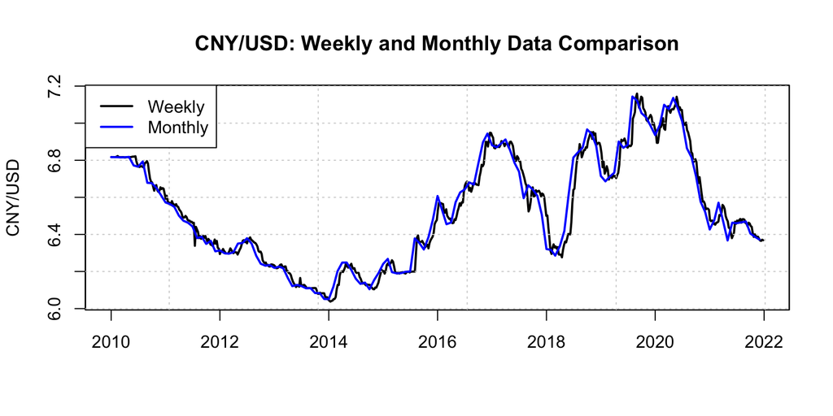

```r
daily <- na.locf(daily)

weekly <- daily
weekly$Date <- floor_date(weekly$Date, "week")
weekly <- aggregate(weekly[, 2:3], by = list(weekly$Date), FUN = mean)
colnames(weekly)[1] <- "Date"

daily <- zoo(daily[-1], daily$Date)
weekly <- zoo(weekly[-1], weekly$Date)
monthly <- zoo(monthly[-1], monthly$Date)
plot(weekly$CNY, xlab = "", ylab = "CNY/USD", col = "black", lwd = 2,
     main = "CNY/USD: Weekly and Monthly Data Comparison")
grid()
lines(monthly$CNY, col = "blue", lwd = 2)
legend("topleft", c("Weekly", "Monthly"), col = c("black", "blue"), lwd = 2)
```

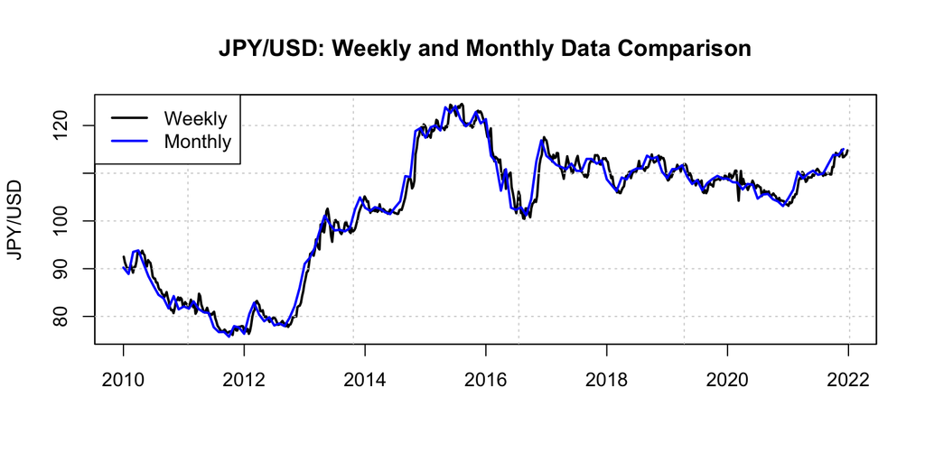

```r
plot(weekly$JPY, xlab = "", ylab = "JPY/USD", col = "black", lwd = 2,
     main = "JPY/USD: Weekly and Monthly Data Comparison")
grid()
lines(monthly$JPY, col = "blue", lwd = 2)
legend("topleft", c("Weekly", "Monthly"), col = c("black", "blue"), lwd = 2)
```

*Response: Weekly vs Montly Time Series data comparison*

**1c.** Fit a non-parametric trend using splines regression to both the weekly and monthly time series data for both currencies. Overlay the fitted trends for each of the currency separately. How do the trends compare when comparing those fitted using the weekly and monthly data? How do the trends for the two currencies compare?

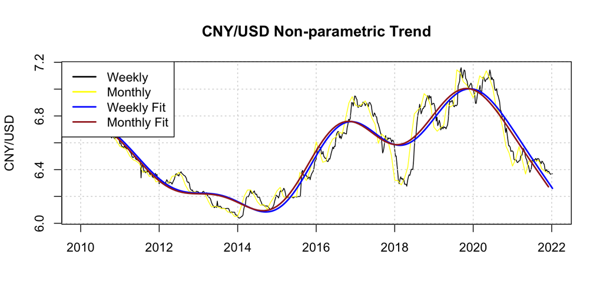

```r
ts_weekly <- ts(weekly, start = 2010, frequency = 52)
ts_monthly <- ts(monthly, start = 2010, frequency = 12)
points_weekly <- 1:nrow(ts_weekly)
points_weekly <- (points_weekly - min(points_weekly)) / max(points_weekly)
points_monthly <- 1:nrow(ts_monthly)
points_monthly <- (points_monthly - min(points_monthly)) / max(points_monthly)
gam.w.CNY <- gam(ts_weekly[, "CNY"] ~ s(points_weekly))
gam.w.JPY <- gam(ts_weekly[, "JPY"] ~ s(points_weekly))
gam.m.CNY <- gam(ts_monthly[, "CNY"] ~ s(points_monthly))
gam.m.JPY <- gam(ts_monthly[, "JPY"] ~ s(points_monthly))
gam.w.CNY.fit <- ts(fitted(gam.w.CNY), start = 2010, frequency = 52)
gam.w.JPY.fit <- ts(fitted(gam.w.JPY), start = 2010, frequency = 52)
gam.m.CNY.fit <- ts(fitted(gam.m.CNY), start = 2010, frequency = 12)
gam.m.JPY.fit <- ts(fitted(gam.m.JPY), start = 2010, frequency = 12)
# Is there a trend for CNY?
ts.plot(ts_weekly[, "CNY"], xlab = "", ylab = "CNY/USD",
        main = "CNY/USD Non-parametric Trend")
grid()
lines(ts_monthly[, "CNY"], col = "yellow")
lines(gam.w.CNY.fit, lwd = 2, col = "blue")
lines(gam.m.CNY.fit, lwd = 2, col = "brown")
legend("topleft", legend = c("Weekly", "Monthly", "Weekly Fit", "Monthly Fit"),
col = c("black", "yellow", "blue", "brown"), lwd = 2)
```

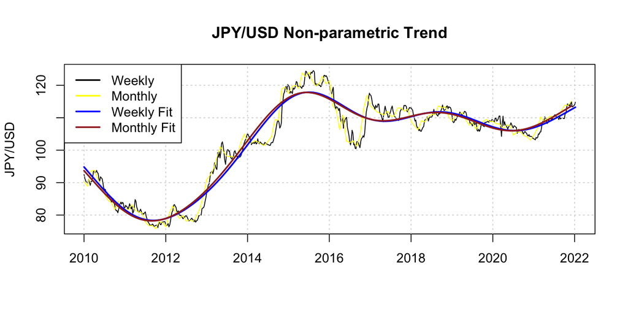

```r
# Is there a trend for JPY?
ts.plot(ts_weekly[, "JPY"], xlab = "", ylab = "JPY/USD",
        main = "JPY/USD Non-parametric Trend")
grid()
lines(ts_monthly[, "JPY"], col = "yellow")
lines(gam.w.JPY.fit, lwd = 2, col = "blue")
lines(gam.m.JPY.fit, lwd = 2, col = "brown")
legend("topleft", legend = c("Weekly", "Monthly", "Weekly Fit", "Monthly Fit"),
col = c("black", "yellow", "blue", "brown"), lwd = 2)
```

*Response: Comparing Trend Estimation using weekly vs Monthly Data*

The trend estimated using weekly and monthly data are almost identical, hence the trend estimation primarily captures the overall pattern regardless whether the data are less or more granular.

**1d.** Take the 1st order difference of the time series weekly vs monthly data. Plot the ACF plots and compare. How do the difference time series for weekly and monthly data compare in terms of stationarity? How do the difference time series for the two currencies compare in terms of serial dependence and stationarity?

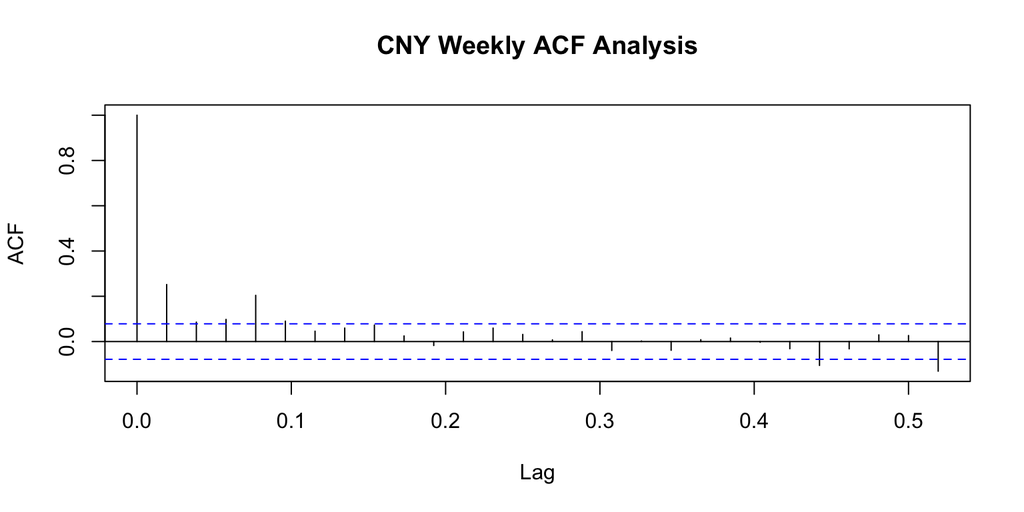

```r
diff_ts_weekly <- diff(ts_weekly)
diff_ts_monthly <- diff(ts_monthly)
acf(diff_ts_weekly[, "CNY"], na.action = na.pass,
    main = "CNY Weekly ACF Analysis")
```

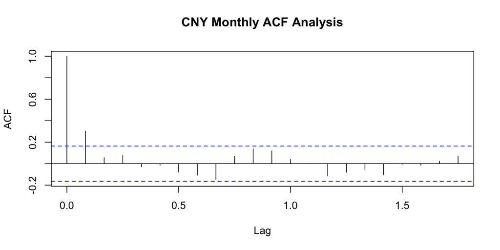

```r
 acf(diff_ts_monthly[, "CNY"], na.action = na.pass,
    main = "CNY Monthly ACF Analysis")
```

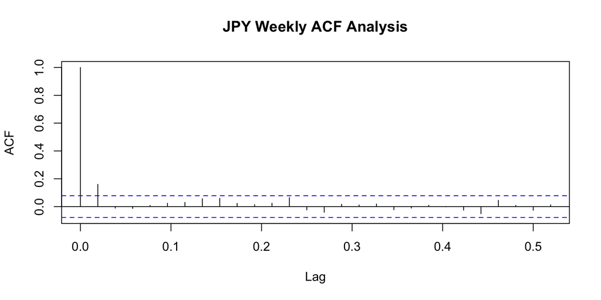

```r
acf(diff_ts_weekly[, "JPY"], na.action = na.pass,
    main = "JPY Weekly ACF Analysis")
```

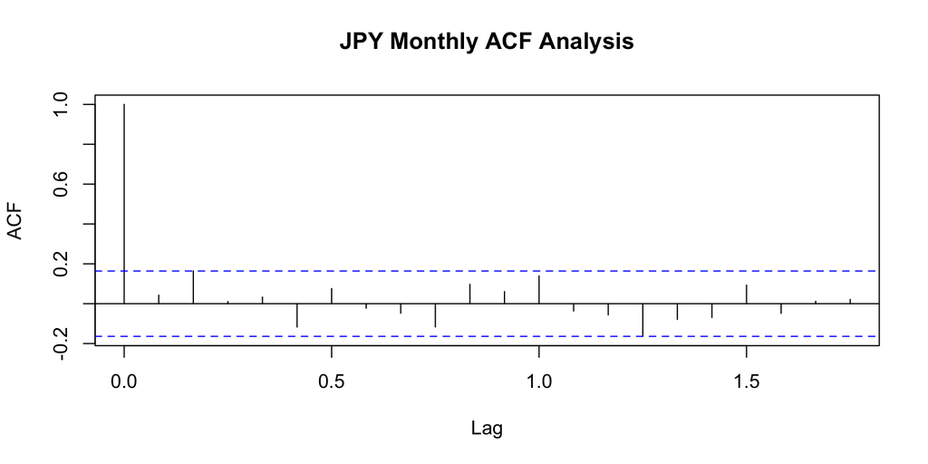

```r
 acf(diff_ts_monthly[, "JPY"], na.action = na.pass,
    main = "JPY Monthly ACF Analysis")
```

*Response: Exploratory Analysis of 1st Order Difference Data*

For both exchange rates, the monthly differenced series appears to perform better in terms of stationarity compared to the weekly differenced series. There still appears to be a somewhat cyclical pattern in the lags for both monthly series, however.

# Question 2. ARIMA Fitting and Forecasting: Weekly Data Analysis (23 points)

**2a.** Divide the data into training and testing data set, where the training data exclude the last eight weeks of data (November and December 2021) with the testing data including the last eight weeks of data. For both currency exchange rates and using the training datasets, use the iterative model to fit an ARIMA(p,d,q) model with max AR and MA orders of 8, and a differencing order of 1 or 2. Display the summary of the final model fit. Compare statistical significance of the coefficients. Would a lower order model be suggested based on the statistical significance of the coefficients?

*Analyzing weekly data with ARIMA model fitting*

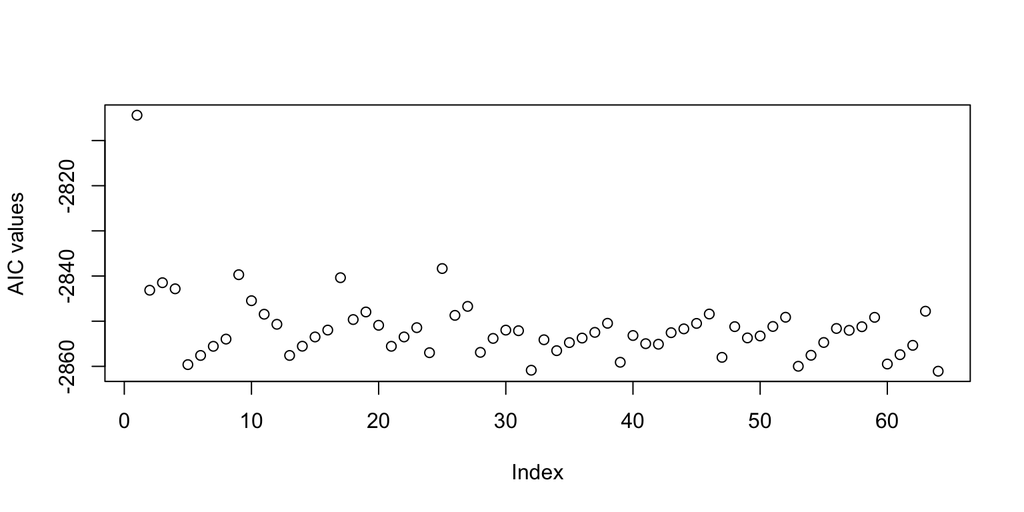

```r
num <- 8
# set up the training and testing data
CNY.w <- ts_weekly[, "CNY"]
JPY.w <- ts_weekly[, "JPY"]
CNY.w.train <- CNY.w[1:(length(CNY.w) - num)]
CNY.w.test <- CNY.w[(length(CNY.w) - num + 1):length(CNY.w)]
JPY.w.train <- JPY.w[1:(length(JPY.w) - num)]
JPY.w.test <- JPY.w[(length(JPY.w) - num + 1):length(JPY.w)]
## CNY Currency Analysis -----
## 1. Differencing Order = 1
n <- length(CNY.w.train)
norder <- num
p <- 1:norder - 1
q <- 1:norder - 1
aic <- matrix(0, norder, norder)
for (i in 1:norder) {
for (j in 1:norder) {
modij = arima(CNY.w.train,
                  order = c(p[i], 1, q[j]),
                  method = 'ML')
    aic[i, j] = modij$aic - 2 * (p[i] + q[j] + 1) + 2 * (p[i] + q[j] + 1) *
      n / (n - p[i] - q[j] - 2)
  }
}
# Extract the "best" one according to AIC
aicv <- as.vector(aic)
plot(aicv, ylab = "AIC values")
```

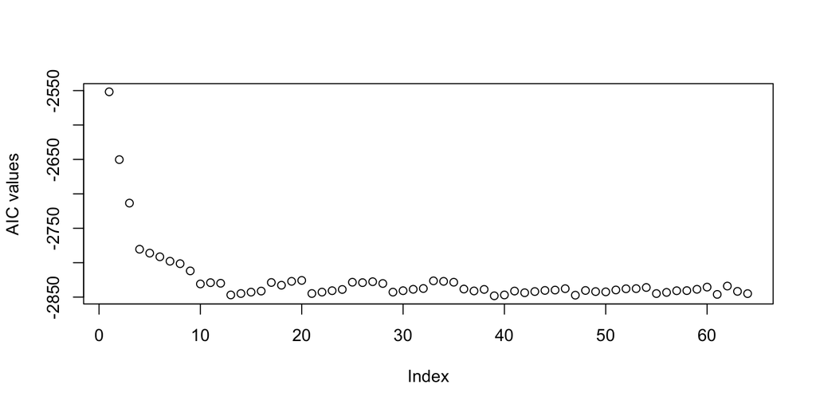

```r
indexp <- rep(c(1:norder), norder)
indexq <- rep(c(1:norder), each = norder)
indexaic <- which(aicv == min(aicv))
porder_1 <- indexp[indexaic] - 1
qorder_1 <- indexq[indexaic] - 1
# Fit the "best" arima model
final_model <- arima(CNY.w.train,
                     order = c(porder_1, 1, qorder_1),
                     method = "ML")
# 2. Differencing Order = 2
for (i in 1:norder) { for (j in 1:norder) {
    modij = arima(CNY.w.train,
                  order = c(p[i], 2, q[j]),
                  method = 'ML')
    aic[i, j] = modij$aic - 2 * (p[i] + q[j] + 1) + 2 * (p[i] + q[j] + 1) *
      n / (n - p[i] - q[j] - 2)
  }
}
# Extract the "best" one according to AIC
aicv <- as.vector(aic)
plot(aicv, ylab = "AIC values")
```

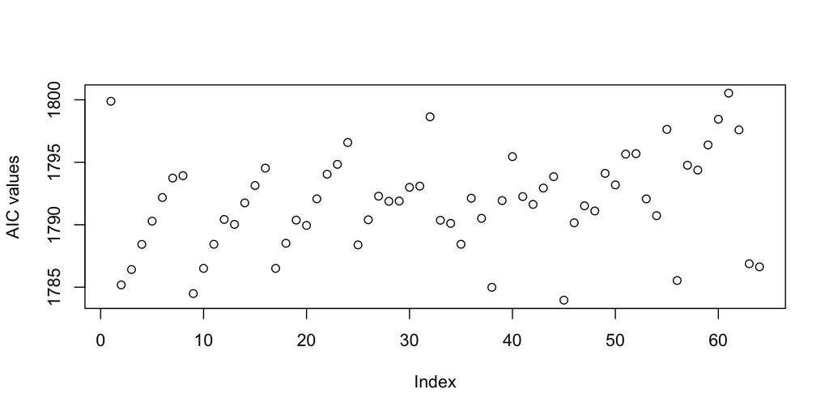

```r
indexp <- rep(c(1:norder), norder)
indexq <- rep(c(1:norder), each = norder)
indexaic <- which(aicv == min(aicv))
porder_2 <- indexp[indexaic] - 1
qorder_2 <- indexq[indexaic] - 1
# Fit the "best" arima model
final_model2 <- arima(CNY.w.train,
                      order = c(porder_2, 2, qorder_2),
method = "ML") ## JPY Currency Analysis -----
## 1. Differencing Order = 1
for (i in 1:norder) { for (j in 1:norder) {
    modij = stats::arima(JPY.w.train,
                         order = c(p[i], 1, q[j]),
                         method = 'ML')
    aic[i, j] = modij$aic - 2 * (p[i] + q[j] + 1) + 2 * (p[i] + q[j] + 1) *
      n / (n - p[i] - q[j] - 2)
  }
}
# Extract the "best" one according to AIC
aicv <- as.vector(aic)
plot(aicv, ylab = "AIC values")
```

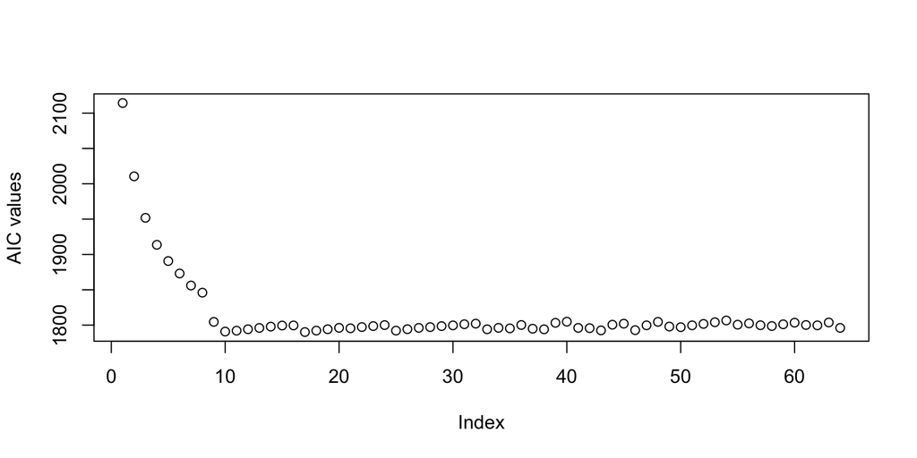

```r
indexp <- rep(c(1:norder), norder)
indexq <- rep(c(1:norder), each = norder)
indexaic <- which(aicv == min(aicv))
porder_3 <- indexp[indexaic] - 1
qorder_3 <- indexq[indexaic] - 1
# Fit the "best" arima model
final_model_JPY <- arima(JPY.w.train,
                        order = c(porder_3, 1, qorder_3),
                        method = "ML")
## 2. Differencing order = 2
for (i in 1:norder) { for (j in 1:norder) {
    modij = stats::arima(JPY.w.train,
                         order = c(p[i], 2, q[j]),
                         method = 'ML')
    aic[i, j] = modij$aic - 2 * (p[i] + q[j] + 1) + 2 * (p[i] + q[j] + 1) *
      n / (n - p[i] - q[j] - 2)
  }
}
# Extract the "best" one according to AIC
aicv <- as.vector(aic)
plot(aicv, ylab = "AIC values")
```

```r
indexp <- rep(c(1:norder), norder)
indexq <- rep(c(1:norder), each = norder)
indexaic <- which(aicv == min(aicv))
porder_4 <- indexp[indexaic] - 1
qorder_4 <- indexq[indexaic] - 1
# Fit the "best" arima model
final_model_JPY2 <- arima(JPY.w.train,
                         order = c(porder_4, 2, qorder_4),
                         method = "ML")
### AIC Summary ----
print("CNY Model Selection:")
```

```
## [1] "CNY Model Selection:"
```

```r
print(paste0("ARIMA: (", porder_1, ", 1, ", qorder_1,
             ") with AICc = ", round(final_model$aic, 3)))
```

```
## [1] "ARIMA: (7, 1, 7) with AICc = -2861.87"
```

```r
 print(paste0("ARIMA: (", porder_2, ", 2, ", qorder_2,
             ") with AICc = ", round(final_model2$aic, 3)))
```

```
## [1] "ARIMA: (6, 2, 4) with AICc = -2848.528"
```

```r
 print("JPY Model Selection:")
```

```
## [1] "JPY Model Selection:"
```

```r
  print(paste0("ARIMA: (", porder_3, ", 1, ", qorder_3,
             ") with AICc = ", round(final_model_JPY$aic, 3)))
```

```
## [1] "ARIMA: (4, 1, 5) with AICc = 1783.601"
```

```r
   print(paste0("ARIMA: (", porder_4, ", 2, ", qorder_4,
             ") with AICc = ", round(final_model_JPY2$aic, 3)))
```

```
## [1] "ARIMA: (0, 2, 2) with AICc = 1790.179"
```

*Response: Analysis of the ARIMA Fit for the Weekly and Monthly Data*

In order to evaluate whether a reduced order for AR or MA will result in a less complex model but with similar explanatory power, we can evaluate the p-value of the z-test for statistical significance of the coefficients corresponding to the highest AR or MA order. Below, I am providing a simple p-value function that can be used to compute the p-values of the z-tests for all coefficients.

```r
## p-value function for the z-test taking as input the test statistic
pvalue.coef <- function(tv){ 2*(1-pnorm(abs(tv)))
}
## compute the test statistics
tv.CNY.weekly <-as.numeric(final_model$coef)/as.numeric(sqrt(diag(final_model$var.coef)))
tv.JPY.weekly <-as.numeric(final_model_JPY$coef)/as.numeric(sqrt(diag(final_model_JPY$var.coef)))
## Apply the pvalue.coef function
pvalues.CNY.weekly <- sapply(tv.CNY.weekly, pvalue.coef)
pvalues.JPY.weekly <- sapply(tv.JPY.weekly, pvalue.coef)
print("CNY T Values:")
```

```
## [1] "CNY T Values:"
```

```r
print(tv.CNY.weekly)
```

```
##  [1] -2.4173374 -1.3809838 -4.9518247  0.1955903 -1.4260701 -0.8466301
##  [7]  9.4468303  4.3498104  1.6890170  4.0156935  1.8835823  1.9505215
## [13]  1.6989226 -5.7396145
```

```r
print("JPY T Values:")
```

```
## [1] "JPY T Values:"
```

```r
print(tv.JPY.weekly)
```

```
## [1]  14.0929193  87.1502940  17.3413583 -68.9092313  -0.2996291 -77.2537456
## [7]  -7.3142605  54.6881370   4.4513687
```

```r
print("CNY P Values:")
```

```
## [1] "CNY P Values:"
```

```r
print(pvalues.CNY.weekly)
```

```
##  [1] 1.563452e-02 1.672839e-01 7.352082e-07 8.449309e-01 1.538481e-01
##  [6] 3.972013e-01 0.000000e+00 1.362553e-05 9.121617e-02 5.927125e-05
## [11] 5.962150e-02 5.111399e-02 8.933377e-02 9.489230e-09
```

```r
print("JPY P Values:")
```

```
## [1] "JPY P Values:"
```

```r
print(pvalues.JPY.weekly)
```

```
## [1] 0.000000e+00 0.000000e+00 0.000000e+00 0.000000e+00 7.644600e-01
## [6] 0.000000e+00 2.589040e-13 0.000000e+00 8.532468e-06
```

*Response: Statistical Significance*

**2b.** Evaluate the model residuals using the ACF and PACF plots, the residual plot and residuals’ histogram as well as hypothesis testing for serial correlation for the selected models in (2a) for the two currencies. Does the model fit the time series data? Compare the model fit for the two currency exchange rates.

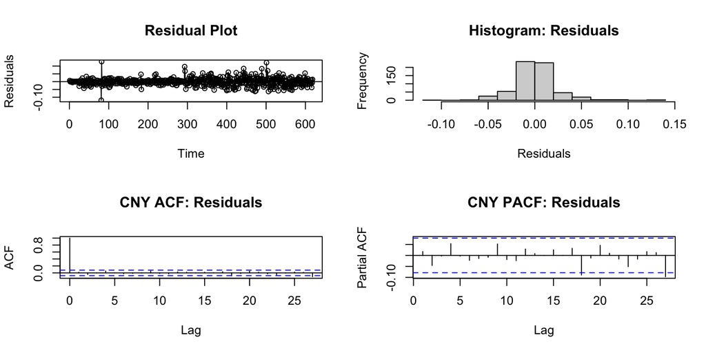

```r
par(mfrow = c(2, 2))
# CNY Residuals
resids <- resid(final_model)
plot(resids,
     ylab = 'Residuals',
     type = 'o',
     main = "Residual Plot")
abline(h = 0)
hist(resids, xlab = 'Residuals', main = 'Histogram: Residuals')
acf(resids, main = "CNY ACF: Residuals")
pacf(resids, main = "CNY PACF: Residuals")
```

```r
Box.test(
  final_model$resid,
  lag = (porder_1 + qorder_1 + 1),
  type = "Box-Pierce",
  fitdf = (porder_1 + qorder_1)
)
```

```
##
##  Box-Pierce test
##
## data:  final_model$resid
## X-squared = 7.3899, df = 1, p-value = 0.006559
```

```r
Box.test(
  final_model$resid,
  lag = (porder_1 + qorder_1 + 1),
  type = "Ljung-Box",
   fitdf = (porder_1 + qorder_1)
)
```

```
##
##  Box-Ljung test
##
## data:  final_model$resid
## X-squared = 7.4959, df = 1, p-value = 0.006184
```

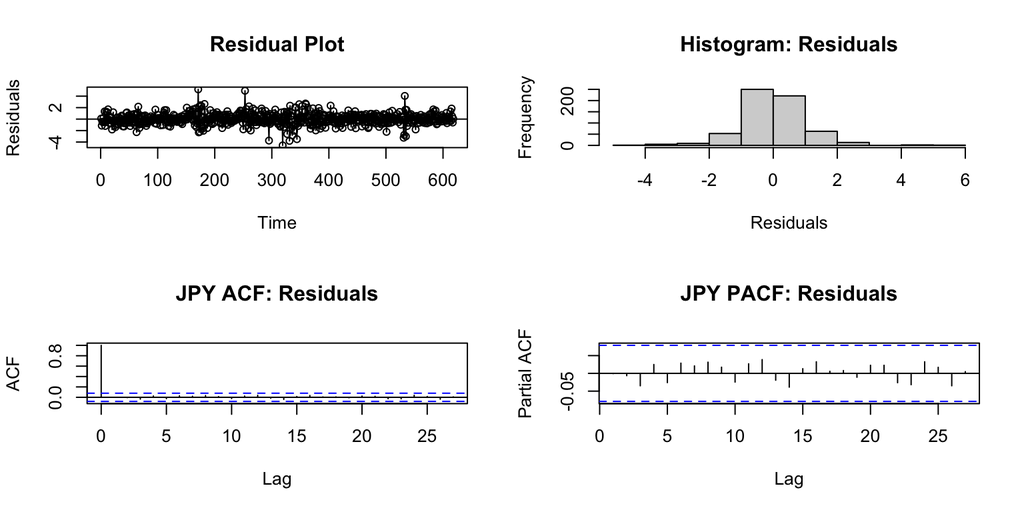

```r
# JPY Residuals
resids <- resid(final_model_JPY)
plot(resids,
     ylab = 'Residuals',
     type = 'o',
     main = "Residual Plot")
abline(h = 0)
hist(resids, xlab = 'Residuals', main = 'Histogram: Residuals')
acf(resids, main = "JPY ACF: Residuals")
pacf(resids, main = "JPY PACF: Residuals")
```

```r
Box.test(
  final_model_JPY$resid,
  lag = (porder_3 + qorder_3 + 1),
  type = "Box-Pierce",
  fitdf = (porder_3 + qorder_3)
)
```

```
##
##  Box-Pierce test
##
## data:  final_model_JPY$resid
## X-squared = 3.5187, df = 1, p-value = 0.06068
```

```r
Box.test(
  final_model_JPY$resid,
  lag = (porder_3 + qorder_3 + 1),
  type = "Ljung-Box",
   fitdf = (porder_3 + qorder_3)
)
```

```
##
##  Box-Ljung test
##
## data:  final_model_JPY$resid
## X-squared = 3.5645, df = 1, p-value = 0.05903
```

*Response: Residual Analysis*

The fit for the JPY data seems to be somewhat better fitting as assessed using the residual plots. The ACF and PACF plots resemble those of white noise. The plots for the CNY data show some heteroskedasticity in the residuals, as well as lags outside of the confidence bands.

Serial correlation testing results: The null hypothesis is that the residual process consists of uncorrelated variables. which is supported since the p-values are larger than 0.05. The p-values for the JPY data are not significant at this level, so we fail to reject the null hypothesis in this case. The tests for the CNY data, however, show evidence of serial correlation in the residual process.

**2c.* For each currency exchange, apply the model identified in (2a) and forecast the last eight weeks of data. Plot the predicted data to compare the predicted values to the actual observed ones. Include 90% confidence intervals for the forecasts in the corresponding plots.

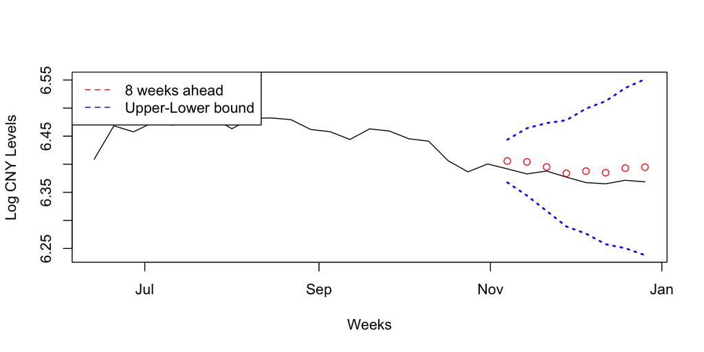

```r
n <- length(CNY.w)
n_fit <- length(CNY.w.train)
n_forward <- n - n_fit
# CNY Data
outpred <- predict(final_model, n.ahead = n_forward) # 90% confidence interval
ubound <- outpred$pred + 1.645 * outpred$se
lbound <- outpred$pred - 1.645 * outpred$se
ymin <- min(lbound)
ymax <- max(ubound)
dates.diff <- index(weekly)
par(mfrow = c(1, 1))
n <- length(CNY.w)
plot((dates.diff)[(n - n_forward - 20):n], CNY.w[(n - n_forward - 20):n],
     type = "l", ylim = c(ymin, ymax), xlab = "Weeks", ylab = "Log CNY Levels")
points((dates.diff)[(n_fit + 1):n], outpred$pred, col = "red")
lines((dates.diff)[(n_fit + 1):n], ubound,
      lty = 3, lwd = 2, col = "blue")
lines((dates.diff)[(n_fit + 1):n], lbound,
      lty = 3, lwd = 2, col = "blue")
legend('topleft',
  legend = c("8 weeks ahead ", "Upper-Lower bound"),
  lty = 2, col = c("red", "blue"))
```

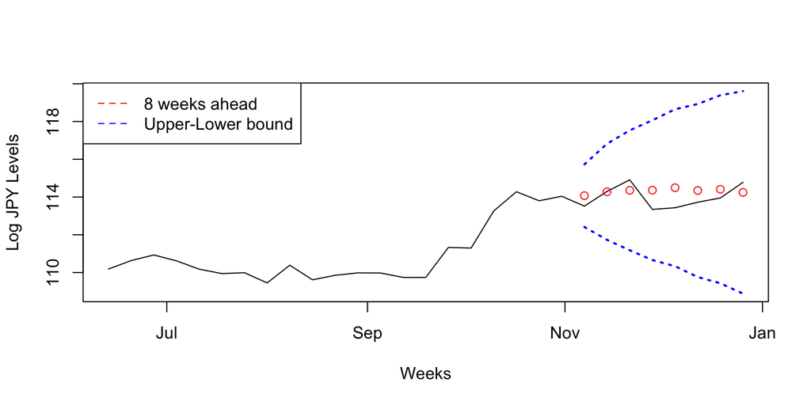

```r
# JPY Data
outpred <- predict(final_model_JPY, n.ahead = n_forward) # 90% confidence interval
ubound <- outpred$pred + 1.645 * outpred$se
lbound <- outpred$pred - 1.645 * outpred$se
ymin <- min(lbound)
ymax <- max(ubound)
dates.diff <- index(weekly)
par(mfrow = c(1, 1))
n <- length(CNY.w)
plot((dates.diff)[(n - n_forward - 20):n], JPY.w[(n - n_forward - 20):n],
     type = "l", ylim = c(ymin, ymax), xlab = "Weeks", ylab = "Log JPY Levels")
points((dates.diff)[(n_fit + 1):n], outpred$pred, col = "red")
lines((dates.diff)[(n_fit + 1):n], ubound,
      lty = 3, lwd = 2, col = "blue")
lines((dates.diff)[(n_fit + 1):n], lbound,
      lty = 3, lwd = 2, col = "blue")
legend('topleft',
  legend = c("8 weeks ahead ", "Upper-Lower bound"),
  lty = 2, col = c("red", "blue"))
```

**2d.** Calculate Mean Absolute Percentage Error (MAPE) and Precision Measure (PM). How many observations are within the prediction bands? Compare the accuracy of the predictions for the two time series using these two measures.

```r
#Computing Accuracy measures
#CNY Data
outpred <- predict(final_model, n.ahead = n_forward)
ubound <- outpred$pred + 1.645 * outpred$se #confidence interval
lbound <- outpred$pred - 1.645 * outpred$se
consump_true <- as.vector(CNY.w[(n_fit + 1):n])
consump_pred <- outpred$pred
print("CNY Stats Summary --------")
```

```
## [1] "CNY Stats Summary --------"
```

```r
print("MAPE:")
```

```
## [1] "MAPE:"
```

```r
print(mean(abs(consump_pred - consump_true) / consump_true))
```

```
## [1] 0.002691736
```

```r
print("PM:")
```

```
## [1] "PM:"
```

```r
print(sum((consump_pred - consump_true)^2) / sum((consump_true - mean(consump_true))^2))
```

```
## [1] 3.860237
```

```r
print("Does the observed data fall outside the prediction intervals?")
```

```
## [1] "Does the observed data fall outside the prediction intervals?"
```

```r
print(sum(consump_true < lbound) & sum(consump_true > ubound))
```

```
## [1] FALSE
```

```r
#JPY Data
outpred <- predict(final_model_JPY, n.ahead = n_forward)
ubound <- outpred$pred + 1.645 * outpred$se #confidence interval
lbound <- outpred$pred - 1.645 * outpred$se
consump_true <- as.vector(JPY.w[(n_fit + 1):n])
consump_pred <- outpred$pred
print("JPY Stats Summary --------")
```

```
## [1] "JPY Stats Summary --------"
```

```r
print("MAPE:")
```

```
## [1] "MAPE:"
```

```r
print(mean(abs(consump_pred - consump_true) / consump_true))
```

```
## [1] 0.005296186
```

```r
print("PM:")
```

```
## [1] "PM:"
```

```r
print(sum((consump_pred - consump_true)^2) / sum((consump_true - mean(consump_true))^2))
```

```
## [1] 1.412865
```

```r
print("Does the observed data fall outside the prediction intervals?")
```

```
## [1] "Does the observed data fall outside the prediction intervals?"
```

```r
print(sum(consump_true < lbound) & sum(consump_true > ubound))
```

```
## [1] FALSE
```

*Response: Prediction Accuracy*

# Question 3. ARIMA Fitting: Monthly Data Analysis (17 points)

**3a.** Divide the data into training and testing data set, where the training data exclude the last two months of data (November and December 2021) with the testing data including the last two months. For both currency exchange rates and using the training datasets, use the iterative model to fit an ARIMA(p,d,q) model with max AR and MA orders of 8, and a differencing order of 1 or 2. Display the summary of the final model fit. Compare statistical significance of the coefficients. Compare the order selection from using monthly versus weekly data for each of the two currencies.

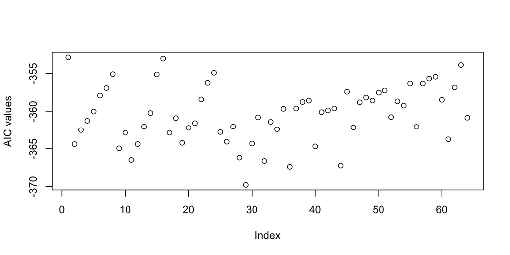

```r
num <- 2
# set up the training and testing data
CNY.m <- ts_monthly[, "CNY"]
JPY.m <- ts_monthly[, "JPY"]
CNY.m.train <- CNY.m[1:(length(CNY.m) - num)]
CNY.m.test <- CNY.m[(length(CNY.m) - num + 1):length(CNY.m)]
JPY.m.train <- JPY.m[1:(length(JPY.m) - num)]
JPY.m.test <- JPY.m[(length(JPY.m) - num + 1):length(JPY.m)]
## CNY Currency Analysis -----
## 1. Differencing Order = 1
n <- length(CNY.m.train)
norder <- 8
p <- 1:norder - 1
q <- 1:norder - 1
aic <- matrix(0, norder, norder)
for (i in 1:norder) {
for (j in 1:norder) {
modij = arima(CNY.m.train,
                  order = c(p[i], 1, q[j]),
method = 'ML')
    aic[i, j] = modij$aic - 2 * (p[i] + q[j] + 1) + 2 * (p[i] + q[j] + 1) *
      n / (n - p[i] - q[j] - 2)
  }
}
# Extract the "best" one according to AIC
aicv <- as.vector(aic)
plot(aicv, ylab = "AIC values")
```

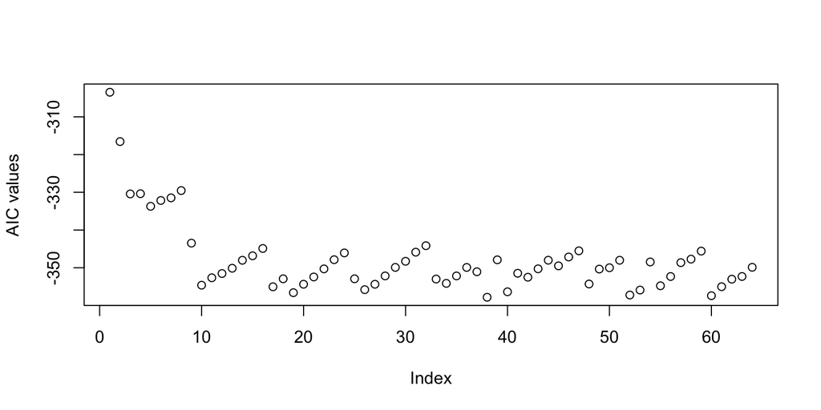

```r
indexp <- rep(c(1:norder), norder)
indexq <- rep(c(1:norder), each = norder)
indexaic <- which(aicv == min(aicv))
porder_5 <- indexp[indexaic] - 1
qorder_5 <- indexq[indexaic] - 1
# Fit the "best" arima model
m_final_model <-
  arima(CNY.m.train,
        order = c(porder_5, 1, qorder_5),
        method = "ML")
# 2. Differencing Order = 2
n = length(CNY.m.train)
norder = 8
p = c(1:norder) - 1
q = c(1:norder) - 1
aic = matrix(0, norder, norder)
for (i in 1:norder) {
for (j in 1:norder) {
modij = arima(CNY.m.train,
                  order = c(p[i], 2, q[j]),
                  method = 'ML')
    aic[i, j] = modij$aic - 2 * (p[i] + q[j] + 1) + 2 * (p[i] + q[j] + 1) *
      n / (n - p[i] - q[j] - 2)
} }
# Extract the "best" one according to AIC
aicv <- as.vector(aic)
plot(aicv, ylab = "AIC values")
```

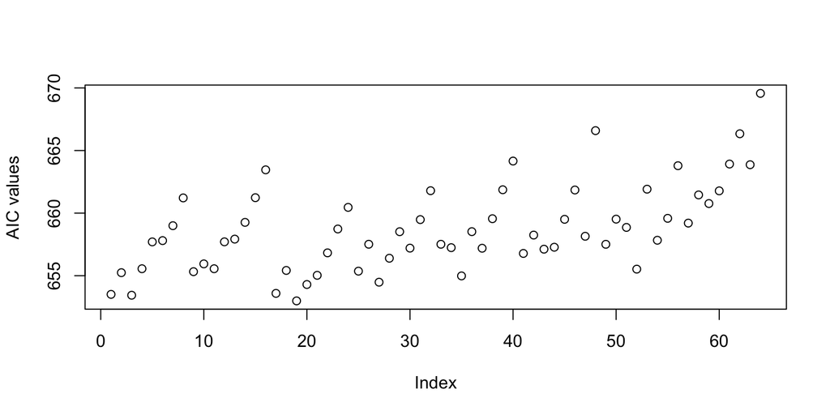

```r
indexp <- rep(c(1:norder), norder)
indexq <- rep(c(1:norder), each = norder)
indexaic <- which(aicv == min(aicv))
porder_6 <- indexp[indexaic] - 1
qorder_6 <- indexq[indexaic] - 1
# Fit the "best" arima model
m_final_model2 <- arima(CNY.m.train,
                        order = c(porder_6, 2, qorder_6),
                        method = "ML")
## JPY Currency Analysis -----
## 1. Differencing Order = 1
n <- length(CNY.m.train)
norder <- 8
p <- 1:norder - 1
q <- 1:norder - 1
aic <- matrix(0, norder, norder)
for (i in 1:norder) {
  for (j in 1:norder) {
  modij <- arima(JPY.m.train,
                   order = c(p[i], 1, q[j]),
                   method = 'ML')
    aic[i, j] <-modij$aic - 2 * (p[i] + q[j] + 1) + 2 * (p[i] + q[j] + 1) * n / (n - p[i] - q[j] - 2)
} }

 # Extract the "best" one according to AIC
aicv <- as.vector(aic)
plot(aicv, ylab = "AIC values")
```

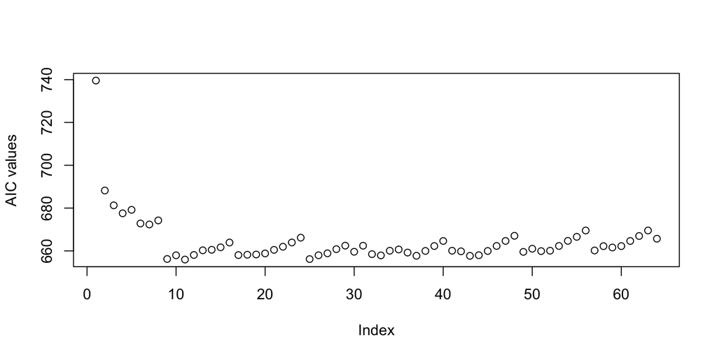

```r
indexp <- rep(c(1:norder), norder)
indexq <- rep(c(1:norder), each = norder)
indexaic <- which(aicv == min(aicv))
porder_7 <- indexp[indexaic] - 1
qorder_7 <- indexq[indexaic] - 1
# Fit the "best" arima model
m_final_model_JPY <- arima(JPY.m.train,
                          order = c(porder_7, 1, qorder_7),method = "ML")
# Differencing Order = 2
n <- length(CNY.m.train)
norder <- 8

p <- 1:norder - 1
q <- 1:norder - 1
aic <- matrix(0, norder, norder)
for (i in 1:norder) {
for (j in 1:norder) {
modij <- arima(JPY.m.train,
                   order = c(p[i], 2, q[j]),
                   method = 'ML')
    aic[i, j] <-
      modij$aic - 2 * (p[i] + q[j] + 1) + 2 * (p[i] + q[j] + 1) * n / (n - p[i] - q[j] - 2)
} }
# Extract the "best" one according to AIC
aicv <- as.vector(aic)
plot(aicv, ylab = "AIC values")
```

```r
indexp <- rep(c(1:norder), norder)
indexq <- rep(c(1:norder), each = norder)
indexaic <- which(aicv == min(aicv))
porder_8 <- indexp[indexaic] - 1
qorder_8 <- indexq[indexaic] - 1
# Fit the "best" arima model
m_final_model_JPY2 <- arima(JPY.m.train,
                           order = c(porder_8, 2, qorder_8),
                           method = "ML")
### AIC Summary ----
print("CNY Model Selection:")
```

```
## [1] "CNY Model Selection:"
```

```r
print(paste0("ARIMA: (", porder_5, ", 1, ", qorder_5,
             ") with AICc = ", round(m_final_model$aic, 3)))
```

```
## [1] "ARIMA: (4, 1, 3) with AICc = -370.856"
```

```r
print(paste0("ARIMA: (", porder_6, ", 2, ", qorder_6,
             ") with AICc = ", round(m_final_model2$aic, 3)))
```

```
## [1] "ARIMA: (5, 2, 4) with AICc = -359.496"
```

```r
print("JPY Model Selection:")
```

```
## [1] "JPY Model Selection:"
```

```r
print(paste0("ARIMA: (", porder_7, ", 1, ", qorder_7,
             ") with AICc = ", round(m_final_model_JPY$aic, 3)))
```

```
## [1] "ARIMA: (2, 1, 2) with AICc = 652.551"
```

```r
print(paste0("ARIMA: (", porder_8, ", 2, ", qorder_8,
             ") with AICc = ", round(m_final_model_JPY2$aic, 3)))
```

```
## [1] "ARIMA: (2, 2, 1) with AICc = 655.676"
```

```r
## compute the test statistics
tv.CNY.monthly <-
  as.numeric(m_final_model$coef) / as.numeric(sqrt(diag(m_final_model$var.coef)))
tv.JPY.monthly <-
  as.numeric(m_final_model_JPY$coef) / as.numeric(sqrt(diag(m_final_model_JPY$var.coef)))
## Apply the pvalue.coef function
pvalues.CNY.monthly <- sapply(tv.CNY.monthly, pvalue.coef)
pvalues.JPY.monthly <- sapply(tv.JPY.monthly, pvalue.coef)
print("CNY T Values:")
```

```
## [1] "CNY T Values:"
```

```r
print(tv.CNY.monthly)
```

```
## [1]   4.4857354  -0.9640226 -11.2791310   3.6221125  -1.1625228  -1.1443232
## [7]  23.1398390
```

```r
print("JPY T Values:")
```

```
## [1] "JPY T Values:"
```

```r
print(tv.JPY.monthly)
```

```
## [1]   2.577382 -16.586686  -4.881611   3.362687
```

```r
print("CNY P Values:")
```

```
## [1] "CNY P Values:"
```

```r
print(pvalues.CNY.monthly)
```

```
## [1] 7.266286e-06 3.350346e-01 0.000000e+00 2.922070e-04 2.450232e-01
## [6] 2.524896e-01 0.000000e+00
```

```r
print("JPY P Values:")
```

```
## [1] "JPY P Values:"
```

```r
print(pvalues.JPY.monthly)
```

```
## [1] 9.955193e-03 0.000000e+00 1.052228e-06 7.718771e-04
```

*Response: Analysis of the ARIMA Fit for the Weekly and Monthly Data*

In order to evaluate whether a reduced order for AR or MA will result in a less complex model but with similar explanatory power, we can evaluate the p-value of the z-test for statistical significance of the coefficients corresponding to the highest AR or MA order. Applying a similar procedure as in previous question, we find that all p-values are approximately zero for the JPY model, suggesting that this model should not be reduced further. The CNY model, however, has one AR coefficient and two MA coefficients which are not significant at the $\alpha=.05$ significance level, so reducing it may be beneficial.

*Response: Monthly vs Weekly Data*

- CNY: Monthly model ARIMA(4,1,3) vs Weekly model ARIMA(7,1,7)
- JPY Monthly model ARIMA(2,1,2) vs Weekly model ARIMA(4,1,5)

Hence the monthly models are less complex for both exchange rates.

**3b.** For each currency exchange, apply the model identified in (3a) and forecast the last two months of data. Plot the predicted data to compare the predicted values to the actual observed ones. Include 90% confidence intervals for the forecasts in the corresponding plots.

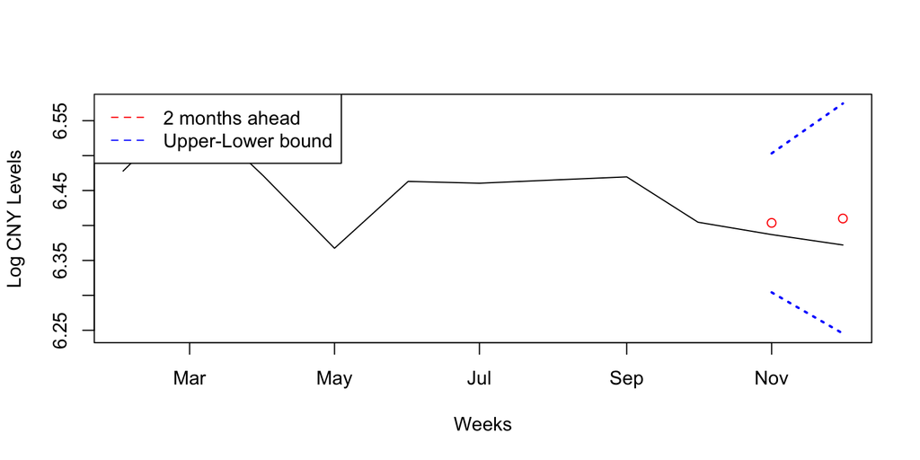

```r
n <- length(CNY.m)
n_fit <- length(CNY.m.train)
n_forward <- n - n_fit
outpred <- predict(m_final_model, n.ahead = n_forward)
ubound <- outpred$pred + 1.645 * outpred$se #confidence interval
lbound <- outpred$pred - 1.645 * outpred$se
ymin <- min(lbound)
ymax <- max(ubound)
dates.diff <- index(monthly)
n <- length(CNY.m)
plot((dates.diff)[(n - n_forward - 8):n],
     CNY.m[(n - n_forward - 8):n],
     type = "l",
     ylim = c(ymin, ymax),
     xlab = "Weeks",
     ylab = "Log CNY Levels"
)
points((dates.diff)[(n_fit + 1):n], outpred$pred, col = "red")
lines((dates.diff)[(n_fit + 1):n],
      ubound,
      lty = 3,
      lwd = 2,
      col = "blue")
lines((dates.diff)[(n_fit + 1):n],
      lbound,
      lty = 3,
      lwd = 2,
      col = "blue")
legend(
  'topleft',
  legend = c("2 months ahead ", "Upper-Lower bound"),
  lty = 2,
  col = c("red", "blue")
)
```

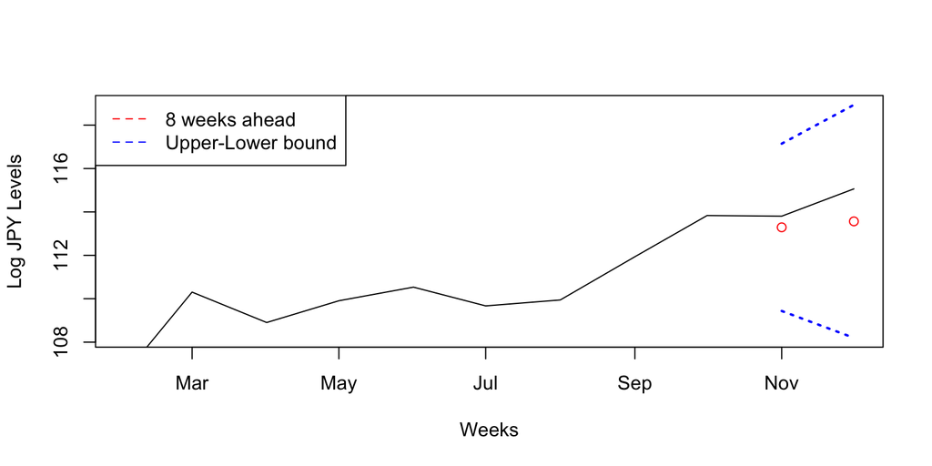

```r
 # JPY Data
outpred <- predict(m_final_model_JPY, n.ahead = n_forward)
ubound <- outpred$pred + 1.645 * outpred$se #confidence interval
lbound <- outpred$pred - 1.645 * outpred$se
ymin <- min(lbound)
ymax <- max(ubound)
dates.diff <- index(monthly)
n <- length(JPY.m)
plot((dates.diff)[(n - n_forward - 8):n],
     JPY.m[(n - n_forward - 8):n],
     type = "l",
     ylim = c(ymin, ymax),
     xlab = "Weeks",
     ylab = "Log JPY Levels"
)
points((dates.diff)[(n_fit + 1):n], outpred$pred, col = "red")
lines((dates.diff)[(n_fit + 1):n],
      ubound,
      lty = 3,
      lwd = 2,
      col = "blue")
lines((dates.diff)[(n_fit + 1):n],
      lbound,
      lty = 3,
      lwd = 2,
      col = "blue")
legend(
  'topleft',
  legend = c("8 weeks ahead ", "Upper-Lower bound"),
  lty = 2,
  col = c("red", "blue")
)
```

**3c.** Calculate Mean Absolute Percentage Error (MAPE) and Precision Measure (PM). How many observations are within the prediction bands? Compare the accuracy of the predictions for the two time series using these two measures.

```r
 #CNY Data
outpred <- predict(m_final_model, n.ahead = n_forward)
ubound <- outpred$pred + 1.645 * outpred$se #confidence interval
 lbound <- outpred$pred - 1.645 * outpred$se
consump_true <- as.vector(CNY.m[(n_fit + 1):n])
consump_pred <- outpred$pred
print("CNY Stats Summary --------")
```

```
## [1] "CNY Stats Summary --------"
```

```r
print("MAPE:")
```

```
## [1] "MAPE:"
```

```r
print(mean(abs(consump_pred - consump_true) / consump_true))
```

```
## [1] 0.004284442
```

```r
print("PM:")
```

```
## [1] "PM:"
```

```r
print(sum((consump_pred - consump_true)^2) / sum((consump_true - mean(consump_true))^2))
```

```
## [1] 15.4665
```

```r
print("Does the observed data fall outside the prediction intervals?")
```

```
## [1] "Does the observed data fall outside the prediction intervals?"
```

```r
print(sum(consump_true < lbound) & sum(consump_true > ubound))
```

```
## [1] FALSE
```

```r
#JPY Data
outpred <- predict(m_final_model_JPY, n.ahead = n_forward)
ubound <- outpred$pred + 1.645 * outpred$se #confidence interval
lbound <- outpred$pred - 1.645 * outpred$se
consump_true <- as.vector(JPY.m[(n_fit + 1):n])
consump_pred <- outpred$pred
print("JPY Stats Summary --------")
```

```
## [1] "JPY Stats Summary --------"
```

```r
print("MAPE:")
```

```
## [1] "MAPE:"
```

```r
print(mean(abs(consump_pred - consump_true) / consump_true))
```

```
## [1] 0.008758606
```

```r
print("PM:")
```

```
## [1] "PM:"
```

```r
print(sum((consump_pred - consump_true)^2) / sum((consump_true - mean(consump_true))^2))
```

```
## [1] 3.159275
```

```r
print("Does the observed data fall outside the prediction intervals?")
```

```
## [1] "Does the observed data fall outside the prediction intervals?"
```

```r
print(sum(consump_true < lbound) & sum(consump_true > ubound))
```

```
## [1] FALSE
```

*Response: Predictions*

All the observations are withing the prediction bands for both the models. However, both models do not seem to provide good predictions due to high PMs.

# Question 4. Weekly vs Monthly Forecasting (5 points)

Compare the forecasts based on the weekly versus monthly data. Overlay the forecast into one single plot for each of the two currency exchange rates. What can you say about using weekly versus monthly data?

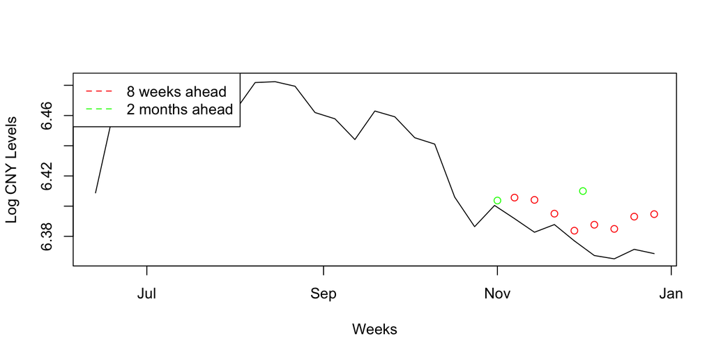

```r
#CNY
n <- length(CNY.w)
n_fit <- length(CNY.w.train)
n_forward <- n - n_fit
outpred <- predict(final_model, n.ahead = n_forward)
ubound <- outpred$pred + 1.645 * outpred$se #confidence interval
lbound <- outpred$pred - 1.645 * outpred$se
ymin <- min(lbound)
ymax <- max(ubound)
dates.diff <- index(weekly)
#monthly
mn <- length(CNY.m)
mn_fit <- length(CNY.m.train)
mn_forward <- mn - mn_fit
moutpred <- predict(m_final_model, n.ahead = mn_forward)
mdates.diff <- index(monthly)
plot((dates.diff)[(n - n_forward - 20):n],
     CNY.w[(n - n_forward - 20):n],
     type = "l",
     xlab = "Weeks",
     ylab = "Log CNY Levels")
points((dates.diff)[(n_fit + 1):n], outpred$pred, col = "red")
points((mdates.diff)[(mn_fit + 1):mn], moutpred$pred, col = "green")
legend(
  'topleft',
  legend = c("8 weeks ahead ", "2 months ahead"),
  lty = 2,
  col = c("red", "green")
)
```

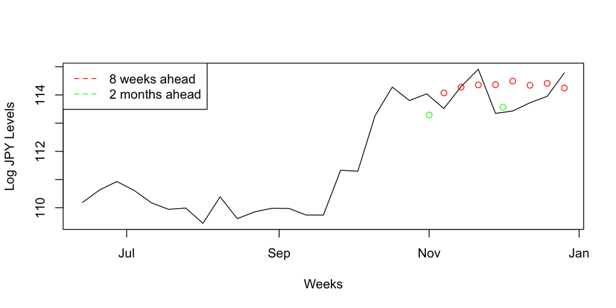

```r
# JPY
n <- length(JPY.w)
n_fit <- length(JPY.w.train)
n_forward <- n - n_fit
outpred <- predict(final_model_JPY, n.ahead = n_forward)
ubound <- outpred$pred + 1.645 * outpred$se #confidence interval
lbound <- outpred$pred - 1.645 * outpred$se
dates.diff <- index(weekly)
#monthly
mn <- length(JPY.m)
mn_fit <- length(JPY.m.train)
mn_forward <- mn - mn_fit
moutpred <- predict(m_final_model_JPY, n.ahead = mn_forward)
mubound <- moutpred$pred + 1.645 * moutpred$se #confidence interval
mlbound <- moutpred$pred - 1.645 * moutpred$se
mdates.diff <- index(monthly)
plot((dates.diff)[(n - n_forward - 20):n],
     JPY.w[(n - n_forward - 20):n],
     type = "l",
     xlab = "Weeks",
     ylab = "Log JPY Levels")
points((dates.diff)[(n_fit + 1):n], outpred$pred, col = "red")
points((mdates.diff)[(mn_fit + 1):mn], moutpred$pred, col = "green")
legend(
  'topleft',
  legend = c("8 weeks ahead ", "2 months ahead"),
  lty = 2,
  col = c("red", "green")
)
```

*Response: Prediction Comparison*

For the CNY currency, the predictions provided by monthly and weekly data overlap slightly, but the monthly model over-predicts for the second month. For JPY, the monthly predictions slightly under-predict, while the weekly predictions slightly over-predict.

# Question 5. Reflection on ARIMA (5 points)

Considering your understanding of the ARIMA model in general as well as what your understanding of the behavior of the currency exchange data based on the completion of the above questions, how would you personally regard the effectiveness of ARIMA modelling? Where would it be appropriate to use it for forecasting and where would you recommend against? What are some specific points of caution one would need to consider when considering using it?

*Response: Reflection on ARIMA*

ARIMA can be a useful tool to analyze time series which can be detrended by differencing. The ARIMA fit the two time series appropriately for both currencies. While the models are good fit, the predictions are poorly capturing the increasing trend. This suggests that a model that would first fit and predict the trend would perform better than the ARIMA model. We also learn that for such time series, we only can perform short term predictions.

The (simple) ARIMA model has other limitations, for example, doesn’t include external factors influencing the variation in the time series, which can be accounted in the extension of ARIMA, called ARIMAX.

*Note: The response to this question will vary from one student to another!*